# Eleigant Graphics with R, Part 1

Just set frequency=FALSE

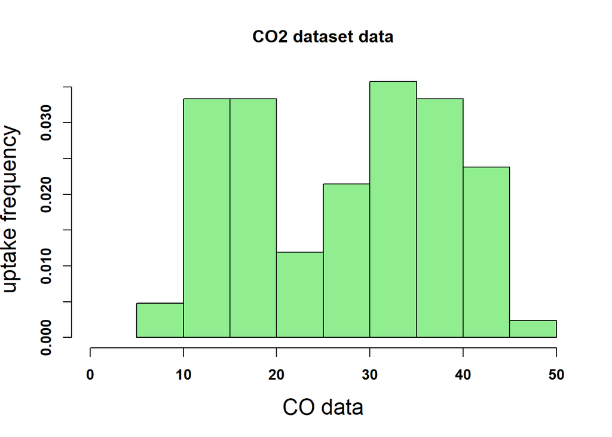

```r
hist(CO2$uptake, freq=FALSE, xlab="CO data",ylab="uptake frequency", main="CO2 dataset data", col="lightgreen", breaks=9, xlim=c(0,50),pch=16,cex=1.5,cex.lab=1.5,font=2)
```

Lets overlay it with distribution curve

*curve(dnorm(x, mean=mean(CO2$ uptake), sd=sd(CO2$ uptake)), add=TRUE, col=“darkblue”, lwd=2)*

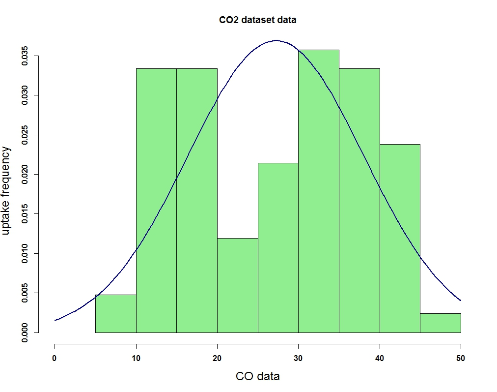

my graph

We can plot the log scale also

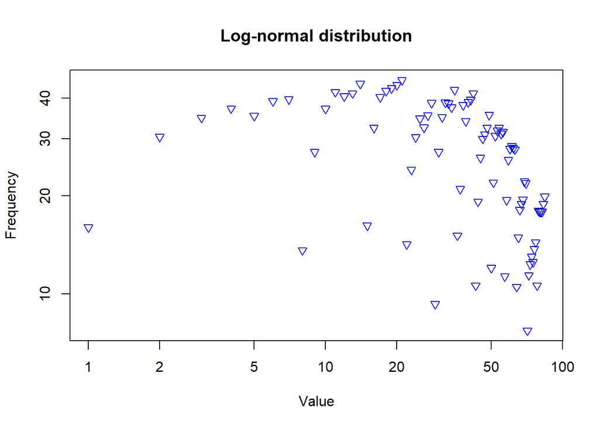

```r
plot(CO2$uptake, log="xy", pch=25, col="blue",main="Log-normal distribution",xlab="Value", ylab="Frequency")
```

## 4. Box and whisker plot

Box plot is more representative than bar plot in several way

Lets see, Lets use “barplot” dataset that we used earlier

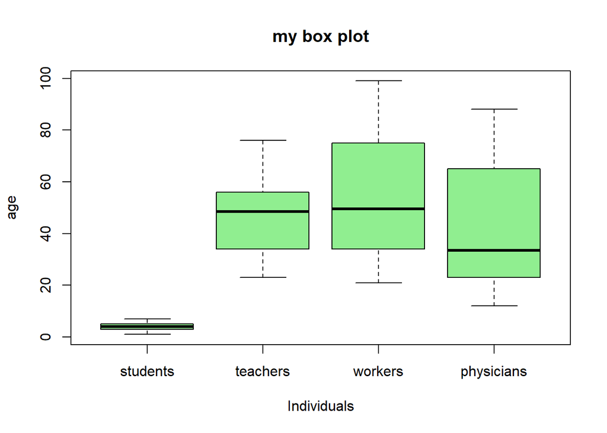

```r
boxplot(for_barplot,col="lightgreen",main="my box plot",xlab="Individuals", ylab="age")
```

Lets boxplot the mtcars data

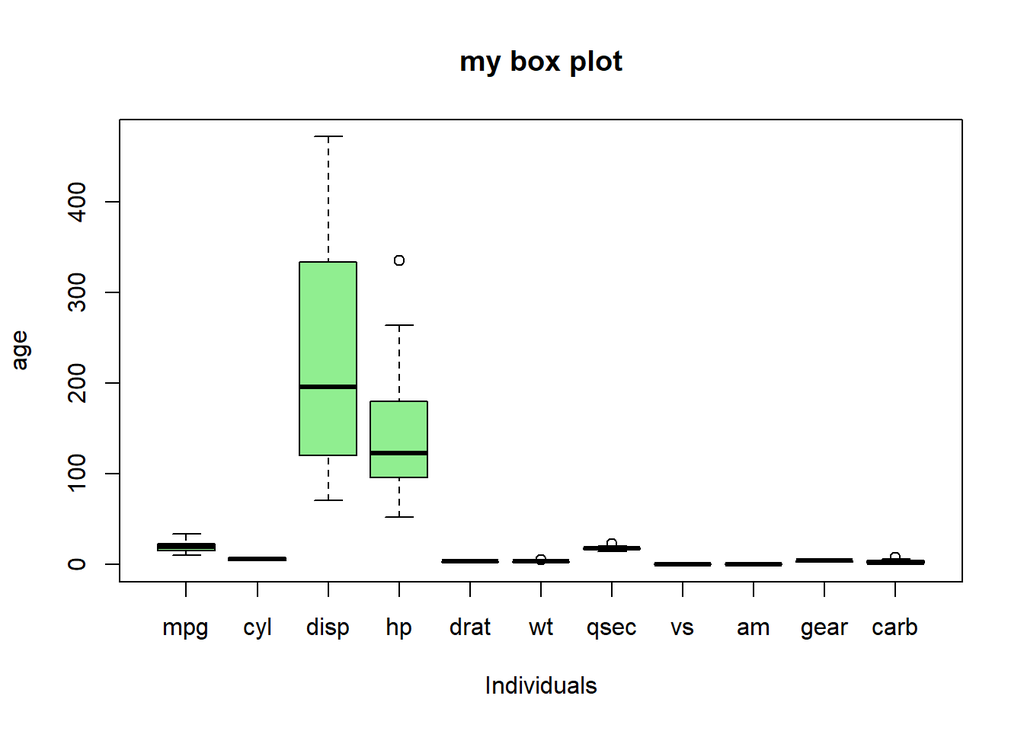

```r
boxplot(mtcars,col="lightgreen",main="my box plot",xlab="Individuals", ylab="age")
```

To understand boxplot, lets discuss this figure

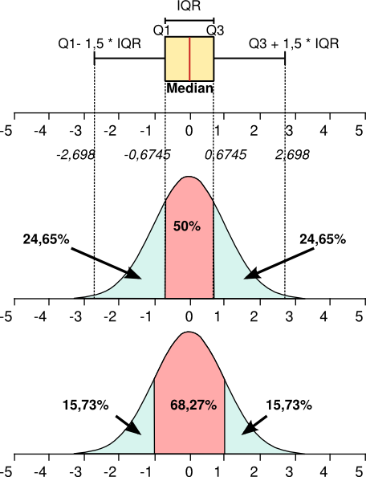

my graph

From this plot you can understand,the differences in medians, interquartile range (fences), and outliers if there is. R calculate this automatically and draw it.

The box plot uses the median and the lower and upper quartiles (defined as the 25th and 75th percentiles). If the lower quartile is Q1 and the upper quartile is Q3, then the difference (Q3 - Q1) is called the interquartile range or IQ.

## 5. Combining graphics (Moderate tip)

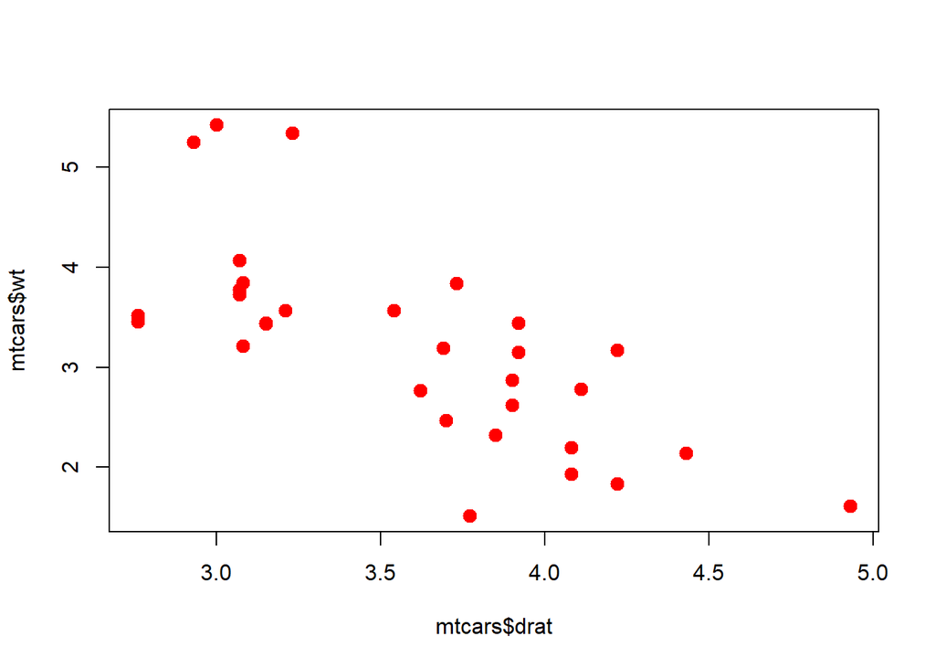

```r
plot(mtcars$drat,mtcars$wt,pch=20,cex=2,col="red") # note that shape 20 is used for filling color but not 21
```

Adding boxplot to scatter plot

Basically i will set a graph size, define where i would like to put my box plot (fixed), then i will ask R to place the box plots in their locations

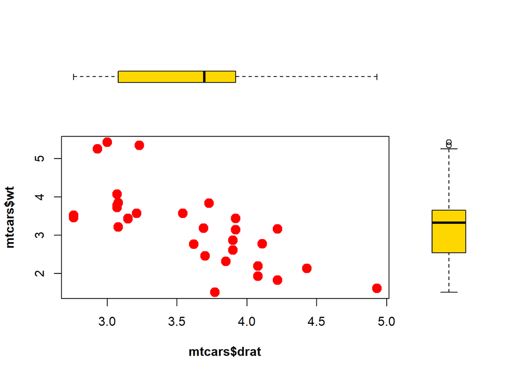

```r
par(fig=c(0,0.8,0,0.8), new=TRUE)# setting main size of the scatter plot
plot(mtcars$drat,mtcars$wt,pch=20,cex=2.5,col="red",font.lab=2)# plottting the main graph # font=2 means bold, 3 means italic
par(fig=c(0,0.8,0.55,1), new=TRUE)#setting the location of the first boxplot for mtcars$drat
boxplot(mtcars$drat, horizontal=TRUE, axes=FALSE,col="gold")# drawing the boxplot of mtcars$drat
par(fig=c(0.65,1,0,0.8),new=TRUE)#setting the location of the first boxplot for mtcars$wt
boxplot(mtcars$wt, axes=FALSE,col="gold")# drawing the boxplot ofmtcars$wt
```